# Communicate Data Findings Project

## Based on data from Bureau of Transportation Statisctic from April 2010 till March 2020

### Project made by Daria Krasnobaeva

This document explores a dataset containing monthly information about different Airlines and their attributes, such like flughts delays and cancellations, for the timeslot of 10 years.

```python
# import all packages and set plots to be embedded inline
import numpy as np
import pandas as pd
import matplotlib.pyplot as plt
import seaborn as sb

%matplotlib inline
```

```python
# load in the dataset into a pandas dataframe, print statistics
df= pd.read_csv('Project_data_airline_delay_causes.csv')
```

```python
# high-level overview of data shape and composition
print(df.shape)
print(df.dtypes)
```

```
(158150, 22)
year                     int64
 month                   int64
carrier                 object
carrier_name            object
airport                 object
airport_name            object
arr_flights            float64
arr_del15              float64
carrier_ct             float64
 weather_ct            float64
nas_ct                 float64
security_ct            float64
late_aircraft_ct       float64
arr_cancelled          float64
arr_diverted           float64
 arr_delay             float64
 carrier_delay         float64
weather_delay          float64
nas_delay              float64
security_delay         float64
late_aircraft_delay    float64
Unnamed: 21            float64
dtype: object
```

```python
print(df.head(10))
```

```
   year   month carrier            carrier_name airport  \
0  2010       4      9E  Pinnacle Airlines Inc.     ABE
1  2010       4      9E  Pinnacle Airlines Inc.     AEX
2  2010       4      9E  Pinnacle Airlines Inc.     ALB
3  2010       4      9E  Pinnacle Airlines Inc.     ALO
4  2010       4      9E  Pinnacle Airlines Inc.     ATL
5  2010       4      9E  Pinnacle Airlines Inc.     ATW
6  2010       4      9E  Pinnacle Airlines Inc.     AUS
7  2010       4      9E  Pinnacle Airlines Inc.     AVL
8  2010       4      9E  Pinnacle Airlines Inc.     AVP
9  2010       4      9E  Pinnacle Airlines Inc.     AZO

                                        airport_name  arr_flights  arr_del15  \
0  Allentown/Bethlehem/Easton, PA: Lehigh Valley ...        109.0        8.0
1           Alexandria, LA: Alexandria International          8.0        0.0
```

[output cut: 46 more lines]

```python
df.info()
```

```
<class 'pandas.core.frame.DataFrame'>
RangeIndex: 158150 entries, 0 to 158149
Data columns (total 22 columns):
year                   158150 non-null int64
 month                 158150 non-null int64
carrier                158150 non-null object
carrier_name           158150 non-null object
airport                158150 non-null object
airport_name           158150 non-null object
arr_flights            157987 non-null float64
arr_del15              157953 non-null float64
carrier_ct             157987 non-null float64
 weather_ct            157987 non-null float64
nas_ct                 157987 non-null float64
security_ct            157987 non-null float64
late_aircraft_ct       157987 non-null float64
arr_cancelled          157987 non-null float64
arr_diverted           157987 non-null float64
 arr_delay             157987 non-null float64
 carrier_delay         157987 non-null float64
weather_delay          157987 non-null float64
nas_delay              157987 non-null float64
security_delay         157987 non-null float64
late_aircraft_delay    157987 non-null float64
Unnamed: 21            0 non-null float64
dtypes: float64(16), int64(2), object(4)
memory usage: 26.5+ MB
```

```python
print(df.describe())
```

```
                year          month    arr_flights      arr_del15  \
count  158150.000000  158150.000000  157987.000000  157953.000000
mean     2014.939589       6.487708     397.778298      73.040537
std         3.082633       3.459573    1051.773244     187.527048
min      2010.000000       1.000000       1.000000       0.000000
25%      2012.000000       3.000000      58.000000       9.000000
50%      2015.000000       6.000000     119.000000      21.000000
75%      2018.000000       9.000000     286.000000      55.000000
max      2020.000000      12.000000   21977.000000    5268.000000

          carrier_ct     weather_ct         nas_ct    security_ct  \
count  157987.000000  157987.000000  157987.000000  157987.000000
mean       20.922144       2.227658      22.693087       0.135372
std        46.020827       6.865975      69.029527       0.576120
min         0.000000       0.000000       0.000000       0.000000
25%         2.900000       0.000000       1.740000       0.000000
50%         7.600000       0.450000       5.180000       0.000000
75%        18.990000       1.880000      14.440000       0.000000
max      1242.160000     295.280000    2401.790000      19.530000

       late_aircraft_ct  arr_cancelled   arr_diverted      arr_delay  \
count     157987.000000  157987.000000  157987.000000  157987.000000
mean          27.046615       6.936824       0.938362    4395.609335
std           77.192888      34.783258       3.963905   12347.436353
min            0.000000       0.000000       0.000000       0.000000
25%            2.070000       0.000000       0.000000     438.000000
50%            6.640000       1.000000       0.000000    1196.000000
75%           18.310000       4.000000       1.000000    3180.000000
max         1849.000000    4951.000000     256.000000  429194.000000

        carrier_delay  weather_delay      nas_delay  security_delay  \
count   157987.000000  157987.000000  157987.000000   157987.000000
mean      1360.134853     204.581915    1056.490458        5.846665
std       3608.829136     729.012316    3793.383559       31.580154
min          0.000000       0.000000       0.000000        0.000000
25%        143.000000       0.000000      58.000000        0.000000
50%        431.000000      20.000000     192.000000        0.000000
75%       1150.000000     146.000000     574.000000        0.000000
max     196944.000000   31960.000000  137443.000000     3194.000000

       late_aircraft_delay  Unnamed: 21
count        157987.000000          0.0
mean           1768.554216          NaN
std            5160.609174          NaN
min               0.000000          NaN
25%             113.000000          NaN
50%             413.000000          NaN
75%            1223.000000          NaN
max          148181.000000          NaN
```

### What is/are the main feature(s) of interest in your dataset?

The main features of interest are information about cause of delay and cancelation of flights of different carries.

### What features in the dataset do you think will help support your investigation into your feature(s) of interest?

There is five cause of delay - Carrier, Weather, NAS, Security and Late Aircraft, as well as there are two cancelation information - cancelated or diverted flight.

I wann analyse per Year which reason was the strongest and which carries had the most cancelation and diverted rate and see if I can find some patterns.

Also I wanna see because of which reason the most delays happen.

## Univariate Exploration

I'll start by looking at the distribution of the data in my data set by carrier and than will go to the distribution the delays reasons and cancelation rate.

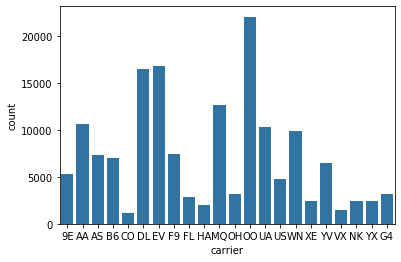

```python
#start with the standart histogram of carrier, presented in the data set
base_color = sb.color_palette()[0]
sb.countplot(data=df, x='carrier', color = base_color);
```

```python
gen_order = df.carrier_name.value_counts().index
```

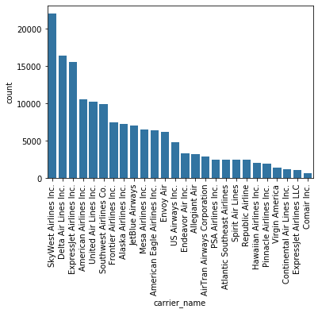

```python
#Do the same observation but with carrier's names and ordered.
base_color = sb.color_palette()[0]
sb.countplot(data=df, x='carrier_name', color = base_color, order = gen_order)
plt.xticks(rotation=90);
```

After observing all the carriers, I decided to continue my observations with some sub DataFrame, that contains only top 5 carriers, that have the most entries.

```python
#creating sub DataFrame
df_sub = df.loc[df['carrier_name'].isin(['United Air Lines Inc.','American Airlines Inc.','SkyWest Airlines Inc.','Delta Air Lines Inc.','ExpressJet Airlines Inc.'])]
```

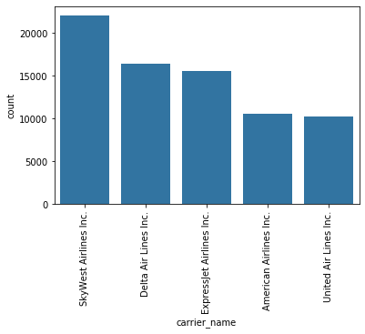

```python
#repeating the simple histogram with only 5 carriers
gen_order = df_sub.carrier_name.value_counts().index
base_color = sb.color_palette()[0]
sb.countplot(data=df_sub, x='carrier_name', color = base_color, order = gen_order)
plt.xticks(rotation=90);
```

Before I continue to work with the top carriers from the dataset, I decided to look into all delays reason of the entire dataframe.

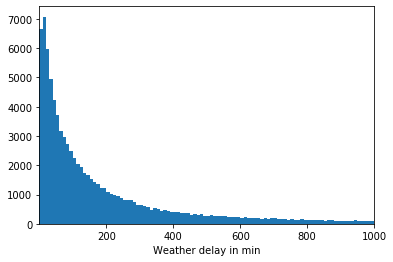

```python
#I start with a standard-scaled plot and excluding 0 for the best picture of
#distribution (excluding all the flights, that didn't have the weather delay:
#The graphic is also having a very long tale, so I firstly limited it too 1.000)


bin_edges=np.arange(0.1,df['weather_delay'].max()+10,10)
plt.hist(data = df, x = 'weather_delay', bins = bin_edges)
plt.xlabel('Weather delay in min')
plt.xlim((0.1,1000));
```

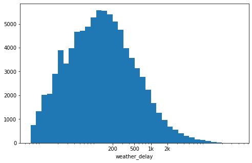

```python
# there's a long tail in the distribution, so let's put it on a log scale instead
log_binsize = 0.1
bins = 10 ** np.arange(0.8, np.log10(df['weather_delay'].max())+log_binsize, log_binsize)

plt.figure(figsize=[8, 5])
plt.hist(data = df, x = 'weather_delay', bins = bins)
plt.xscale('log')
plt.xticks([2e2, 5e2, 1e3, 2e3], ['200', '500', '1k', '2k'])
plt.xlabel('weather_delay')
plt.show()
```

Wheather delays have a long-tailed distribution, with a lot of short delays and few very very long delays, one even longer than 3.000 min. When plotted on a log-scale, the delay distribution looks roughly unimodal and still skewed to the right.

Next up, the second variable of interest: carrier delay.

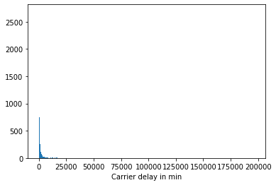

```python
# Againg I start with a standard-scaled plot and excluding 0 for the best picture of
#distribution (excluding all the flights, that didn't have the weather delay:
#The graphic is also having a very long tale, so I firstly limited it too 1.000)
bin_edges=np.arange(0.1,df[' carrier_delay'].max()+10,10)
plt.hist(data = df, x = ' carrier_delay', bins = bin_edges)
plt.xlabel('Carrier delay in min')
#plt.xlim((0.1,1000));
```

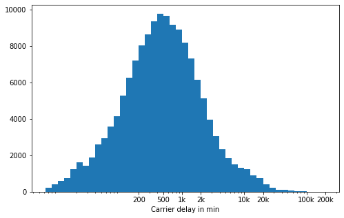

```python
# there's a long tail in the distribution again, so let's put it on a log scale instead
log_binsize = 0.1
bins = 10 ** np.arange(0.8, np.log10(df[' carrier_delay'].max())+log_binsize, log_binsize)

plt.figure(figsize=[8, 5])
plt.hist(data = df, x = ' carrier_delay', bins = bins)
plt.xscale('log')
plt.xticks([2e2, 5e2, 1e3,2e3,1e4,2e4,1e5,2e5], ['200', '500', '1k', '2k','10k','20k','100k','200k'])
plt.xlabel('Carrier delay in min')
plt.show()
```

Carrier delays have although a long-tailed distribution, with a lot of short delays and few very very long delays. When plotted on a log-scale, the delay distribution looks roughly unimodal, still skewed to the right and has one peak around 500.

Next up, the third variable of interest: nas delay.

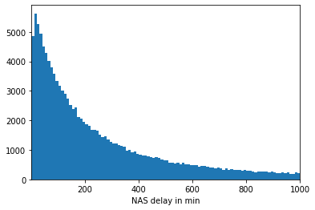

```python
bins =np.arange(1,df['nas_delay'].max()+10,10)
plt.hist(data = df, x = 'nas_delay', bins = bins);
plt.xlabel('NAS delay in min')
plt.xlim((1,1000));
```

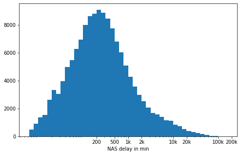

```python
# there's a long tail in the distribution again, so let's put it on a log scale instead
log_binsize = 0.1
bins = 10 ** np.arange(0.8, np.log10(df['nas_delay'].max())+log_binsize, log_binsize)

plt.figure(figsize=[8, 5])
plt.hist(data = df, x = 'nas_delay', bins = bins)
plt.xscale('log')
plt.xticks([2e2, 5e2, 1e3,2e3,1e4,2e4,1e5,2e5], ['200', '500', '1k', '2k','10k','20k','100k','200k'])
plt.xlabel('NAS delay in min')
plt.show()
```

NAS delays have although a long-tailed distribution, with a lot of short delays and few very very long delays. When plotted on a log-scale, the delay distribution looks roughly unimodal, skewed to the right and has one peak at 200.

Next up, the third variable of interest: security delay.

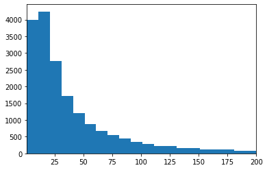

```python
bins =np.arange(1,df['security_delay'].max()+10,10)
plt.hist(data = df, x = 'security_delay', bins = bins);
plt.xlim((1,200));
```

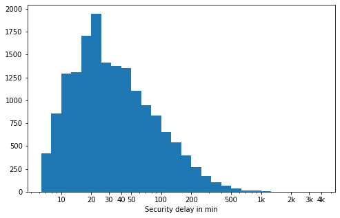

```python
# there's a long tail in the distribution again, so let's put it on a log scale instead
log_binsize = 0.1
bins = 10 ** np.arange(0.8, np.log10(df['security_delay'].max())+log_binsize, log_binsize)

plt.figure(figsize=[8, 5])
plt.hist(data = df, x = 'security_delay', bins = bins)
plt.xscale('log')
plt.xticks([10,20,30,40,50,1e2, 2e2, 5e2, 1e3,2e3,3e3,4e3], ['10','20','30','40','50','100','200', '500', '1k', '2k','3k','4k'])
plt.xlabel('Security delay in min')
plt.show()
```

Next up, the fifth variable of interest: late aircraft delay.

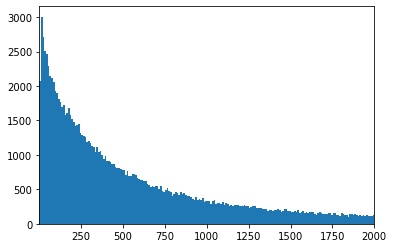

```python
bins =np.arange(1,df['late_aircraft_delay'].max()+10,10)
plt.hist(data = df, x = 'late_aircraft_delay', bins = bins);
plt.xlabel('Late aircraft delay in min')
plt.xlim((1,2000));
```

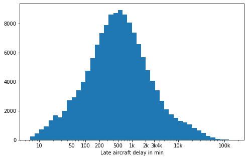

```python
log_binsize = 0.1
bins = 10 ** np.arange(0.8, np.log10(df['late_aircraft_delay'].max())+log_binsize, log_binsize)

plt.figure(figsize=[8, 5])
plt.hist(data = df, x = 'late_aircraft_delay', bins = bins)
plt.xscale('log')
plt.xticks([10, 50, 1e2, 2e2, 5e2, 1e3,2e3,3e3,4e3,1e4,1e5], ['10','50','100','200', '500', '1k', '2k','3k','4k','10k','100k'])
plt.xlabel('Late aircraft delay in min')
plt.show()
```

Late aircraft delays have although a long-tailed distribution, with a lot of short delays and few very very long delays. When plotted on a log-scale, the delay distribution looks roughly unimodal, start at appr. 5 with a pick around 500.

### Discuss the distribution(s) of your variable(s) of interest. Were there any unusual points? Did you need to perform any transformations?

> Every distibution of delays in min was skewed to the right, so I needed perform the log transformation, adjust xtickts and bins.

## Bivariate Exploration

> In this section, I will investigate relationships between pairs of variables in the data. I gonna start with th devolopment of cancelation and answer the question which year got the most of cancelation so far.

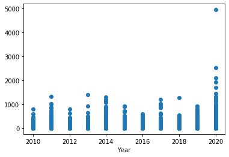

```python
#I will use a simple scatteplot for it
plt.scatter(data = df, x ='year', y='arr_cancelled')
plt.xlabel('Year');
#it's interesting to see the impact of corona virus on the data
```

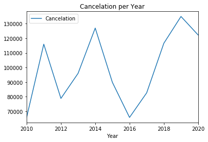

```python
# Also I will use a subplot for it for more detailed observation
fig, ax = plt.subplots()
sums = df.groupby(['year'])['arr_cancelled'].sum().reset_index(level=0)

# Use ax
sums.plot(x='year',y='arr_cancelled', ax=ax, label='Cancelation')
ax.set_title("Cancelation per Year")
plt.xlabel('Year');
```

In the first scatteplot we could already see the impact of Corona Virus on our data (outliers in 2020). In the Subplot we see, that after only 3 Month of 2020 we almost reach the level of cancelation of 2019. The 2019 is the year with the most cancelations, according to the data. My guess, that after the actualisation of data 2020 that will hit the bar.

In the next step we are going to use our sub DataFrame to analyse the different reasons of delay and figure out, which one has the biggest impact.

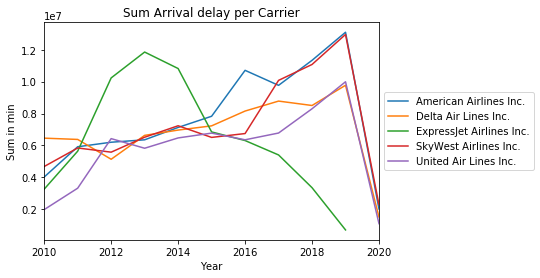

```python
# making a loop through all top 5 carrier
fig, ax = plt.subplots()
sums = df_sub.groupby(['carrier_name', 'year'])[' arr_delay'].sum().reset_index(level=0)

for carrier in sums['carrier_name'].unique():
    sums[sums['carrier_name'] == carrier].plot(y=' arr_delay', ax=ax, label=carrier)

ax.set_title("Sum Arrival delay per Carrier")

plt.legend(loc='center left', bbox_to_anchor=(1.0, 0.5))
plt.xlabel('Year')
plt.ylabel('Sum in min')
plt.show()
```

I also interested not only in summary of all delays, but in mean. I also decided that mean values are more interesting for my observation and will continue do them for the next 4 kinds of delays.

[figure not shown]

```python
# making a loop for mean per Year
fig, ax = plt.subplots()
sums = df_sub.groupby(['carrier_name', 'year'])[' arr_delay'].mean().reset_index(level=0)

# Use ax for both
for carrier in sums['carrier_name'].unique():
    sums[sums['carrier_name'] == carrier].plot(y=' arr_delay', ax=ax, label=carrier)

ax.set_title("Average Arrival Delay per Carrier")

plt.legend(loc='center left', bbox_to_anchor=(1.0, 0.5))
plt.xlabel('Year')
plt.ylabel('Ave Delay in min')
plt.show()
```

In the next steps development of carrier delays observed.

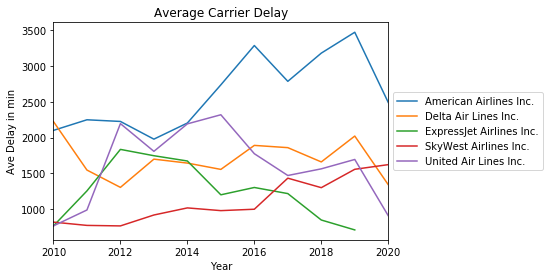

```python
# making a loop for mean per Year
fig, ax = plt.subplots()
sums = df_sub.groupby(['carrier_name', 'year'])[' carrier_delay'].mean().reset_index(level=0)

# Use ax for both
for carrier in sums['carrier_name'].unique():
    sums[sums['carrier_name'] == carrier].plot(y=' carrier_delay', ax=ax, label=carrier)

ax.set_title("Average Carrier Delay")

plt.legend(loc='center left', bbox_to_anchor=(1.0, 0.5))
plt.xlabel('Year')
plt.ylabel('Ave Delay in min')
plt.show()
```

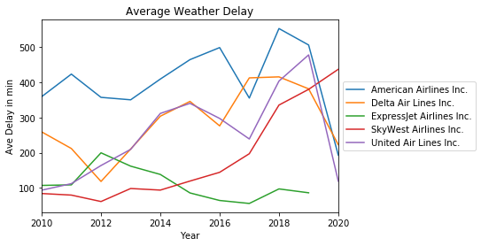

```python
# weather delays
fig, ax = plt.subplots()
sums = df_sub.groupby(['carrier_name', 'year'])['weather_delay'].mean().reset_index(level=0)

# Use ax for both
for carrier in sums['carrier_name'].unique():
    sums[sums['carrier_name'] == carrier].plot(y='weather_delay', ax=ax, label=carrier)

ax.set_title("Average Weather Delay")

plt.legend(loc='center left', bbox_to_anchor=(1.0, 0.5))
plt.xlabel('Year')
plt.ylabel('Ave Delay in min')
plt.show()
```

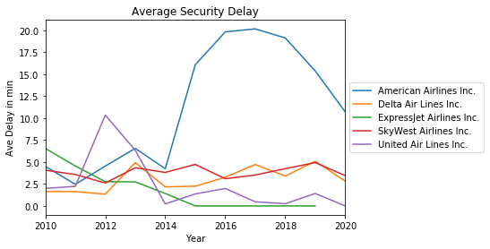

```python
#security delays
fig, ax = plt.subplots()
sums = df_sub.groupby(['carrier_name', 'year'])['security_delay'].mean().reset_index(level=0)

# Use ax for both
for carrier in sums['carrier_name'].unique():
    sums[sums['carrier_name'] == carrier].plot(y='security_delay', ax=ax, label=carrier)

ax.set_title("Average Security Delay")

plt.legend(loc='center left', bbox_to_anchor=(1.0, 0.5))
plt.xlabel('Year')
plt.ylabel('Ave Delay in min')
plt.show()
```

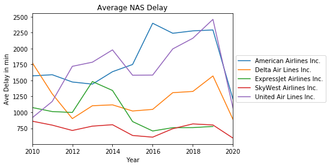

```python
# Nas delay
fig, ax = plt.subplots()
sums = df_sub.groupby(['carrier_name', 'year'])['nas_delay'].mean().reset_index(level=0)

# Use ax for both
for carrier in sums['carrier_name'].unique():
    sums[sums['carrier_name'] == carrier].plot(y='nas_delay', ax=ax, label=carrier)

ax.set_title("Average NAS Delay")

plt.legend(loc='center left', bbox_to_anchor=(1.0, 0.5))
plt.xlabel('Year')
plt.ylabel('Ave Delay in min')
plt.show()
```

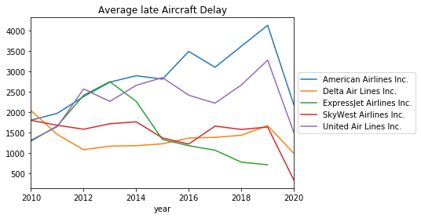

```python
# Late aircraft delay
fig, ax = plt.subplots()
sums = df_sub.groupby(['carrier_name', 'year'])['late_aircraft_delay'].mean().reset_index(level=0)

# Use ax for both
for carrier in sums['carrier_name'].unique():
    sums[sums['carrier_name'] == carrier].plot(y='late_aircraft_delay', ax=ax, label=carrier)

ax.set_title("Average late Aircraft Delay")

plt.legend(loc='center left', bbox_to_anchor=(1.0, 0.5))
plt.show()
```

### Talk about some of the relationships you observed in this part of the investigation. How did the feature(s) of interest vary with other features in the dataset?

> After the observation it is clear, that American Airlines Inc. having the most if delays, espacially a lot Carrier delays. Express Airlines Inc. showed the interesting development from having a lot of delays to have less delays than other carriers. Sadly there is now data for 2020 from this company available.

## Multivariate Exploration

In the next step I will continue work with df_sub (containing the top 5 carirer) and on their example I wanna figure out which art of dealys caused most of it.

```python
df_sub= df_sub.rename(columns={" carrier_delay": "carrier_delay"})
```

```python
#for my analysis I will creat a new dataframe only with mean information per year per delay art.
weather_by_year=df_sub.query('weather_delay>0.0').groupby('year')['weather_delay'].mean().reset_index(name='weather_delay')
carrier_by_year=df_sub.query('carrier_delay>0.0').groupby('year')['carrier_delay'].mean().reset_index(name='carrier_delay')
nas_by_year=df_sub.query('nas_delay>0.0').groupby('year')['nas_delay'].mean().reset_index(name='nas_delay')
security_by_year=df_sub.query('security_delay>0.0').groupby('year')['security_delay'].mean().reset_index(name='security_delay')
lateaircraft_by_year=df_sub.query('late_aircraft_delay>0.0').groupby('year')['late_aircraft_delay'].mean().reset_index(name='late_aircraft_delay')
```

```python
temp=weather_by_year.merge(nas_by_year,on='year')
temp=temp.merge(security_by_year,on='year')
temp=temp.merge(carrier_by_year,on='year')
delays_by_year=temp.merge(lateaircraft_by_year,on='year')
```

```python
delays_by_year
```

|  | year | weather_delay | nas_delay | security_delay | carrier_delay | late_aircraft_delay |
| --- | --- | --- | --- | --- | --- | --- |
| 0 | 2010 | 254.390424 | 1280.448732 | 31.094991 | 1348.954069 | 1770.729693 |
| 1 | 2011 | 295.772678 | 1170.394068 | 29.847352 | 1344.302443 | 1762.392822 |
| 2 | 2012 | 300.873741 | 1128.137890 | 45.189655 | 1613.860509 | 2063.783104 |
| 3 | 2013 | 298.230970 | 1319.520483 | 63.517958 | 1620.967614 | 2212.617883 |
| 4 | 2014 | 351.986772 | 1329.425021 | 40.964206 | 1682.686156 | 2149.161213 |
| 5 | 2015 | 390.407184 | 1110.188695 | 53.178571 | 1628.072218 | 1823.591651 |
| 6 | 2016 | 394.707450 | 1196.125335 | 57.755102 | 1784.391674 | 1863.415783 |
| 7 | 2017 | 440.620735 | 1349.520412 | 65.389423 | 1768.732865 | 1902.183266 |
| 8 | 2018 | 522.304231 | 1412.697103 | 63.455975 | 1703.561978 | 2015.155193 |
| 9 | 2019 | 607.088938 | 1604.499149 | 59.959569 | 2060.219858 | 2450.998442 |
| 10 | 2020 | 463.452257 | 953.531193 | 50.979452 | 1711.233100 | 1309.565522 |

Now we got a new Dataframe with mean information about delays per Year. I wanna transform this data, so I see all the delays types in one column.

```python
#melting the df
delays_df= df_sub.melt(id_vars = ['year'],
                          value_vars = ['weather_delay','nas_delay','security_delay','carrier_delay','late_aircraft_delay'],
                          var_name = 'delays_types', value_name = 'delay_min').dropna()
delays_df.head()
```

|  | year | delays_types | delay_min |
| --- | --- | --- | --- |
| 0 | 2010 | weather_delay | 212.0 |
| 1 | 2010 | weather_delay | 77.0 |
| 2 | 2010 | weather_delay | 340.0 |
| 3 | 2010 | weather_delay | 15.0 |
| 4 | 2010 | weather_delay | 16.0 |

```python
#Transforming the DF to have only one entry per year per delay
delays_mean= delays_df.groupby(['delays_types','year'])['delay_min'].mean().reset_index(level=0)

delays_mean
```

| year | delays_types | delay_min |
| --- | --- | --- |
| 2010 | carrier_delay | 1294.130267 |
| 2011 | carrier_delay | 1296.985701 |
| 2012 | carrier_delay | 1552.942958 |
| 2013 | carrier_delay | 1563.020408 |
| 2014 | carrier_delay | 1626.178038 |
| 2015 | carrier_delay | 1554.754503 |
| 2016 | carrier_delay | 1674.566093 |
| 2017 | carrier_delay | 1668.836946 |
| 2018 | carrier_delay | 1606.958682 |
| 2019 | carrier_delay | 1970.609338 |
| 2020 | carrier_delay | 1590.723727 |
| 2010 | late_aircraft_delay | 1678.689626 |
| 2011 | late_aircraft_delay | 1666.574481 |
| 2012 | late_aircraft_delay | 1940.537465 |
| 2013 | late_aircraft_delay | 2081.091220 |
| 2014 | late_aircraft_delay | 2030.590752 |
| 2015 | late_aircraft_delay | 1697.357437 |
| 2016 | late_aircraft_delay | 1705.689312 |
| 2017 | late_aircraft_delay | 1754.892341 |
| 2018 | late_aircraft_delay | 1869.140070 |
| 2019 | late_aircraft_delay | 2302.008513 |
| 2020 | late_aircraft_delay | 1012.323944 |
| 2010 | nas_delay | 1220.740107 |
| 2011 | nas_delay | 1122.393935 |
| 2012 | nas_delay | 1069.347606 |
| 2013 | nas_delay | 1257.348856 |
| 2014 | nas_delay | 1268.835554 |
| 2015 | nas_delay | 1038.623520 |
| 2016 | nas_delay | 1096.203317 |
| 2017 | nas_delay | 1245.998675 |
| 2018 | nas_delay | 1323.515570 |
| 2019 | nas_delay | 1504.618117 |
| 2020 | nas_delay | 852.806067 |
| 2010 | security_delay | 3.851123 |
| 2011 | security_delay | 3.010999 |
| 2012 | security_delay | 3.691549 |
| 2013 | security_delay | 4.602246 |
| 2014 | security_delay | 2.440165 |
| 2015 | security_delay | 4.023289 |
| 2016 | security_delay | 4.519656 |
| 2017 | security_delay | 4.913656 |
| 2018 | security_delay | 4.890101 |
| 2019 | security_delay | 5.917797 |
| 2020 | security_delay | 4.031961 |
| 2010 | weather_delay | 169.339679 |
| 2011 | weather_delay | 171.124293 |
| 2012 | weather_delay | 164.124507 |
| 2013 | weather_delay | 187.818929 |
| 2014 | weather_delay | 219.851013 |
| 2015 | weather_delay | 233.531009 |
| 2016 | weather_delay | 221.938084 |
| 2017 | weather_delay | 241.057322 |
| 2018 | weather_delay | 354.468193 |
| 2019 | weather_delay | 405.856478 |
| 2020 | weather_delay | 289.218310 |

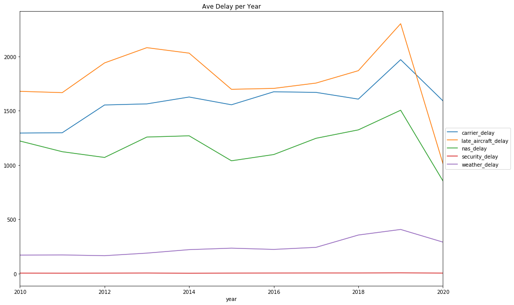

```python
# making a loop for mean per Year
fig, ax = plt.subplots(figsize = [15,10])
#sums = delays.groupby(['delays_types','year'])['late_aircraft_delay'].mean().reset_index(level=0)

# Use ax for both
for reason in delays_mean['delays_types'].unique():
    delays_mean[delays_mean['delays_types'] == reason].plot(y='delay_min', ax=ax, label=reason)

ax.set_title("Ave Delay per Year")

plt.legend(loc='center left', bbox_to_anchor=(1.0, 0.5))
plt.show()
```

### Talk about some of the relationships you observed in this part of the investigation. Were there features that strengthened each other in terms of looking at your feature(s) of interest?

> According to my analysis late aircraft delays are the most popular delays. On the econd place it is carrier delay followed by nas delay and weather delay.

### Were there any interesting or surprising interactions between features?

> For me it was interesting to see, that weather delays actually playing not such a big roll in the whole picture. As well as that due to Corona Virus the carrie delay went on the 1st place in 2020.